CS F364: Design and Analysis of Algorithms

# Selection: Randomized & Deterministic

Lecture 9 |2026-06-02

# Selection: Finding the Median

- Selection: Finding the Median
- Randomized Select
- Deterministic Select

## Problem Definition

- Given an unsorted array $A$ of $n$ distinct integers, find the $k^{\text{th}}$ smallest element.
- Can we do it faster than sorting ($O(n \log n)$)?
- This problem was solved in 1972 by **Blum, Floyd, Pratt, Rivest, and Tarjan**.
- Today, we will study:
  - A **linear-time randomized** algorithm.
  - A **linear-time deterministic** algorithm.

## Algorithm Approach

- In RANDOMIZED-QUICKSORT, after the partition step we can tell which subarray has the item we are looking for, just by looking at their sizes.
- So, we only need to recursively examine **one** subarray, not two.

# Randomized Select

- Selection: Finding the Median
- Randomized Select
- Deterministic Select

## QuickSelect

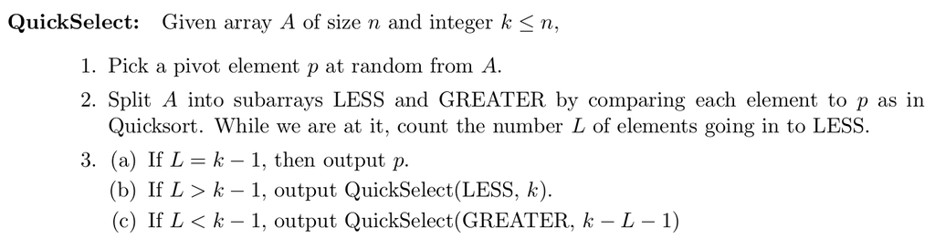

QuickSelect Algorithm

## Algorithm Analysis

**Theorem**

The expected number of comparisons for QuickSelect is $O(n)$.

**Proof:**

- Let $T(n, k)$ denote the expected time to find the $k^{\text{th}}$ smallest in an array of size $n$,
- and let $T(n) = \max_k T(n, k)$.
- We will show that $T(n) \leq 4n$.
- First, it takes $n-1$ comparisons to split the array into two parts. As with Quicksort, these parts might have size $0$ and $n-1$, or $1$ and $n-2$, and so on. Each of these is equally likely.

## Analysis (Continued)

Since we are giving an upper bound, we consider the worst case and imagine we always recurse on the larger part:

$$T(n) \leq (n-1) + \frac{2}{n} \sum_{i=n/2}^{n-1} T(i)$$

Assuming $T(i) \leq 4i$ for $i < n$:

$$\begin{align*}
T(n) &\leq (n-1) + \frac{2}{n} \sum_{i=n/2}^{n-1} 4i \\
&= (n-1) + \frac{8}{n} \cdot \frac{3n^2 - 2n}{8} \\
&\leq (n-1) + 3n \\
&< 4n
\end{align*}$$

Thus $T(n) = O(n)$. The expected running time of QuickSelect is linear!

# Deterministic Select

- Selection: Finding the Median
- Randomized Select
- Deterministic Select

## Deterministic Select

**Problem:** Given an array $A$ of $n$ numbers, and an integer $i$, find the $i^{\text{th}}$ smallest element in $A$.

- Deterministic Partition.
- **Median of median** trick.

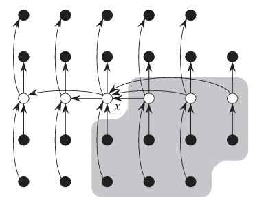

Group of 5 Medians

## Algorithm: Select

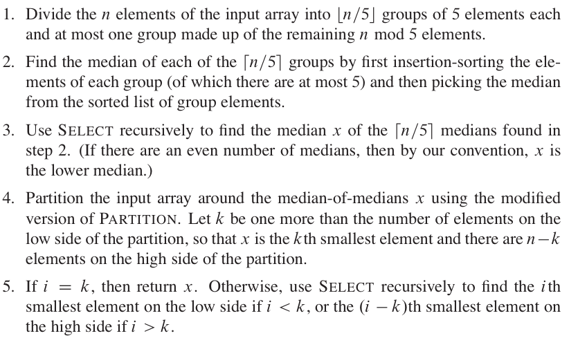

Deterministic Select Algorithm

## Recurrence Analysis

$$T(n) = T(n/5) + T(7n/10 + 6) + O(n)$$

- $T(n/5)$: Time to find the median of the $\lceil n/5 \rceil$ medians (recursive call).
- $T(7n/10 + 6)$: Recursive call on the larger partition (at most $7n/10 + 6$ elements).
- $O(n)$: Partitioning and grouping overhead.

Solving this recurrence gives $T(n) = O(n)$.